# Description

The Aarhus University Signal Processing group, in collaboration with University of Southern Denmark, has recently released a dataset containing images of unique plants belonging to 12 species at several growth stages.

The ability to do so effectively can mean better crop yields and better stewardship of the environment.

## Objective

To implement the techniques learnt during "Introduction to coomputer vision".

## Data Description

- Labels.csv : A csv formated file contains the labels for each images.
- images.npy : A standard binary file format contains all the images needed for analysis.

### Importing necessary libraries

```python
# This will help in making the Python code more structured automatically (good coding practice)
%load_ext nb_black

# Import necessary libraries
import warnings

# Suppress warnings
warnings.filterwarnings("ignore")

# Libraries to help with reading and manipulating data
import numpy
import numpy as np
import pandas as pd

# Import matplotlib.pyplot (Plotting framework in Python.)
import matplotlib.pyplot as plt

from PIL import Image

# fixing random
seed = 1
# GLOBAL VARIABLES
scale = 100
BATCH_SIZE = 64
EPOCHS = 30

# Fix seed
numpy.random.seed(seed)

from sklearn.model_selection import train_test_split

import sklearn.metrics as metrics

# To show images using cv2 module
from google.colab.patches import (
    cv2_imshow,
)

# To show images using cv2 module
import cv2

import seaborn as sns
from sklearn.metrics import accuracy_score, confusion_matrix
from sklearn.utils import class_weight

# To perform one-hot encoding
from tensorflow.keras.utils import to_categorical

from keras.callbacks import EarlyStopping
from keras.callbacks import ModelCheckpoint
from keras.layers import LeakyReLU

# Sequential groups a linear stack of layers into a tf.keras.Model.
from tensorflow.keras.models import Sequential, clone_model
from tensorflow.keras.layers import BatchNormalization

# This layer creates a convolution kernel that is convolved with the layer input to produce a tensor of outputs.
from tensorflow.keras.layers import Conv2D

# Max pooling operation for 2D spatial data.
from tensorflow.keras.layers import MaxPooling2D

# Flattens the input. Does not affect the batch size.
from tensorflow.keras.layers import Flatten

# Dropout: Applies Dropout to the input.
# Dense: Just your regular densely-connected NN layer.
from tensorflow.keras.layers import Dense, Dropout

# Generate batches of tensor image data with real-time data augmentation.
from tensorflow.keras.preprocessing.image import ImageDataGenerator
```

### Load data

Load data set from "Labels" csv file and "Images" npy file.

```python
npy_array = np.load("images.npy")
```

```python
df_labels = pd.read_csv("Labels.csv")
```

### Review data

Review the load data set for both structure and relevance.

```python
print("Image data shape:\n", npy_array.shape)
print("\nLabels data shape:", df_labels.shape)
```

```
Image data shape:
 (4750, 128, 128, 3)

Labels data shape: (4750, 1)
```

### Data Pre-processing

- Resize the image to 100 X 100 format.
- Convert all the image from RGB to Grey scale to build efficient model.

```python
images_array = []
images_grey = []
images_blur = []
labels_array = df_labels.to_numpy()
column_names = ["Label", "Image", "Image_Grey", "Image_Blur"]
data_df = pd.DataFrame(columns=column_names)
ulabel_array = df_labels.groupby("Label").nunique().index
```

```python
index = 0
for npy_image in npy_array:

    lbl = labels_array[index]

    resizeImage = cv2.resize(npy_image, (scale, scale))
    greyImage = cv2.cvtColor(resizeImage, cv2.COLOR_BGR2GRAY)
    blurImage = cv2.GaussianBlur(resizeImage, (5, 5), cv2.BORDER_DEFAULT)
    images_array.append(npy_image)
    images_grey.append(greyImage)
    images_blur.append(blurImage)

    data_df.loc[len(data_df.index)] = [lbl[0], npy_image, greyImage, blurImage]

    index += 1
```

```python
data_df.info()
```

```
<class 'pandas.core.frame.DataFrame'>
Int64Index: 4750 entries, 0 to 4749
Data columns (total 4 columns):
 #   Column      Non-Null Count  Dtype
---  ------      --------------  -----
 0   Label       4750 non-null   object
 1   Image       4750 non-null   object
 2   Image_Grey  4750 non-null   object
 3   Image_Blur  4750 non-null   object
dtypes: object(4)
memory usage: 185.5+ KB
```

```python
data_df.head()
```

|  | Label | Image | Image_Grey | Image_Blur |
| --- | --- | --- | --- | --- |
| 0 | Small-flowered Cranesbill | [[[35, 52, 78], [36, 49, 76], [31, 45, 69], [4... | [[57, 54, 62, 76, 80, 82, 73, 58, 55, 57, 61, ... | [[[50, 66, 85], [52, 68, 87], [59, 75, 93], [6... |
| 1 | Small-flowered Cranesbill | [[[30, 47, 63], [30, 50, 60], [34, 47, 63], [2... | [[50, 50, 41, 51, 62, 67, 70, 67, 60, 60, 45, ... | [[[30, 47, 64], [30, 48, 64], [33, 51, 66], [3... |
| 2 | Small-flowered Cranesbill | [[[154, 149, 144], [162, 156, 152], [161, 154,... | [[149, 154, 146, 79, 55, 53, 55, 74, 146, 158,... | [[[151, 147, 146], [138, 134, 135], [117, 114,... |
| 3 | Small-flowered Cranesbill | [[[49, 48, 57], [47, 48, 58], [48, 50, 56], [5... | [[51, 52, 58, 62, 74, 83, 90, 101, 88, 93, 73,... | [[[59, 61, 69], [59, 61, 69], [62, 63, 72], [6... |
| 4 | Small-flowered Cranesbill | [[[53, 67, 80], [48, 62, 75], [43, 55, 68], [3... | [[68, 61, 54, 60, 64, 68, 72, 78, 81, 80, 83, ... | [[[47, 61, 74], [46, 60, 73], [43, 56, 71], [3... |

### Exploratory data analysis.

```python
data_df.groupby("Label")
data_df["Label"].value_counts()
```

```
Loose Silky-bent             654
Common Chickweed             611
Scentless Mayweed            516
Small-flowered Cranesbill    496
Fat Hen                      475
Charlock                     390
Sugar beet                   385
Cleavers                     287
Black-grass                  263
Shepherds Purse              231
Common wheat                 221
Maize                        221
Name: Label, dtype: int64
```

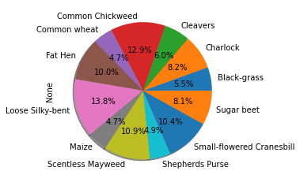

```python
data_df.groupby("Label").size().plot.pie(autopct="%1.1f%%", shadow=True, startangle=0)
```

**Observation**:

```python
classes = [
    "Black-grass",
    "Charlock",
    "Cleavers",
    "Common Chickweed",
    "Common wheat",
    "Fat Hen",
    "Loose Silky-bent",
    "Maize",
    "Scentless Mayweed",
    "Shepherds Purse",
    "Small-flowered Cranesbill",
    "Sugar beet",
]
```

#### Display sample original and processed image for each class.

```python
def show_seedling():
    index = 0
    for c in classes:
        print("Class {}".format(c))
        label_df = data_df[data_df["Label"] == c]
        for index in range(1):
            fig, axs = plt.subplots(1, 3, figsize=(5, 5))
            axs[0].imshow(label_df.iloc[index]["Image"])
            axs[1].imshow(label_df.iloc[index]["Image_Grey"])
            axs[2].imshow(label_df.iloc[index]["Image_Blur"])
            plt.show()
```

```
Display images (original, gray and blurred) from each class.

Class Black-grass
```

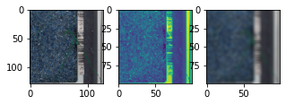

```
Class Charlock
```

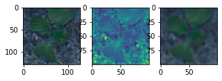

```
Class Cleavers
```

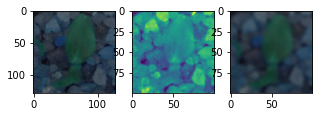

```
Class Common Chickweed
```

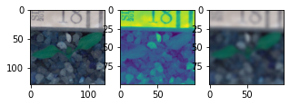

```
Class Common wheat
```

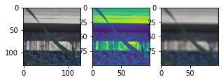

```
Class Fat Hen
```

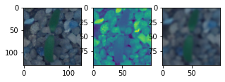

```
Class Loose Silky-bent
```

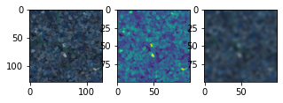

```
Class Maize
```

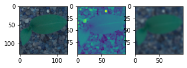

```
Class Scentless Mayweed
```

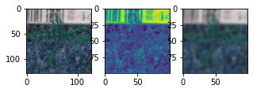

```
Class Shepherds Purse
```

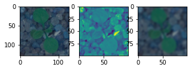

```
Class Small-flowered Cranesbill
```

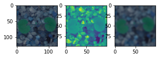

```
Class Sugar beet
```

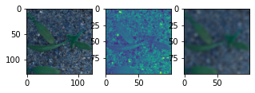

```python
print("Display images (original, gray and blurred) from each class.\n")
show_seedling()
```

#### Observation:

- Following images has data like labels that may skew the training and prediction.
  - Black-grass
  - Common Chickweed
  - Common wheat
  - Scentless Mayweed
- Few images have weeds that may affect the training and prediction.

#### Find and display mean images for each class.

- Find the mean for each class of images and check for any pattern.

```python
Black_grass_data = []
Charlock_data = []
Cleavers_data = []
Common_Chickweed_data = []
Common_wheat_data = []
Fat_Hen_data = []
Loose_Silky_bent_data = []
Maize_data = []
Scentless_Mayweed_data = []
Shepherds_Purse_data = []
Small_flowered_Cranesbill_data = []
Sugar_beet_data = []

for cla in classes:
    label_df = data_df[data_df["Label"] == cla]
    if cla == "Black-grass":
        Black_grass_data = label_df["Image_Grey"].tolist()
    if cla == "Charlock":
        Charlock_data = label_df["Image_Grey"].tolist()
    if cla == "Cleavers":
        Cleavers_data = label_df["Image_Grey"].tolist()
    if cla == "Common Chickweed":
        Common_Chickweed_data = label_df["Image_Grey"].tolist()
    if cla == "Common wheat":
        Common_wheat_data = label_df["Image_Grey"].tolist()
    if cla == "Fat Hen":
        Fat_Hen_data = label_df["Image_Grey"].tolist()
    if cla == "Loose Silky-bent":
        Loose_Silky_bent_data = label_df["Image_Grey"].tolist()
    if cla == "Maize":
        Maize_data = label_df["Image_Grey"].tolist()
    if cla == "Scentless Mayweed":
        Scentless_Mayweed_data = label_df["Image_Grey"].tolist()
    if cla == "Shepherds Purse":
        Shepherds_Purse_data = label_df["Image_Grey"].tolist()
    if cla == "Small-flowered Cranesbill":
        Small_flowered_Cranesbill_data = label_df["Image_Grey"].tolist()
    if cla == "Sugar beet":
        Sugar_beet_data = label_df["Image"].tolist()
```

```python
def find_mean_img(full_mat, title):
    # calculate the average
    mean_img = np.mean(full_mat, axis=0)
    # reshape it back to a matrix
    # mean_img = mean_img.reshape((scale, scale))
    plt.imshow(mean_img, vmin=0, vmax=255, cmap="Greys_r")
    plt.title(f"Average {title}")
    plt.axis("off")
    plt.show()
    return mean_img
```

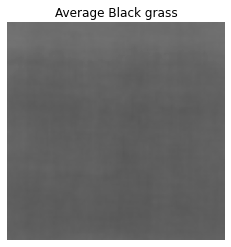

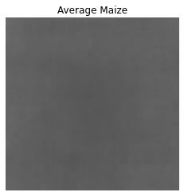

```python
black_grass_mean = find_mean_img(np.array(Black_grass_data), "Black grass")
black_grass_mean = find_mean_img(np.array(Maize_data), "Maize")
```

**Observation**:

- Mean calculation extracted no meaningful information because the seedling's pictures are not of standard format.
- There is no structure or commonality to the image.

### Data Preparation

```python
cleanSeedlingData = data_df.copy()
X = numpy.asarray(images_grey)
y = cleanSeedlingData.pop("Label")
```

### Data Normalization

- Scale pixel values to the range 0-1 to normalize images.
- Deducing pixel values to its finest help to speed up the model learning process.

```python
# Normalizing pixel values
X = X / 255.0
# Add channel 1 to indicate grey channel for ImageDataGenerator
X = X.reshape(-1, scale, scale, 1)
```

### Display normalized images.

```
Image before and after normalization using plot imshow
```

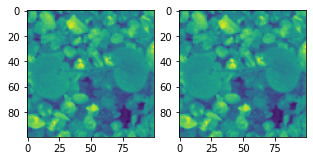

```
Image before and after normalization using cv2 imshow
```

```python
print("\nImage before and after normalization using plot imshow")
fig, axs = plt.subplots(1, 2, figsize=(5, 5))
axs[0].imshow(X[0])
axs[1].imshow(images_grey[0])
plt.show()
print("Image before and after normalization using cv2 imshow\n")
cv2_imshow(X[0])
cv2_imshow(images_grey[0])
cv2_imshow((X[0] * 255))
```

[output not shown]

#### **Observation**:

- cv2 image show function displays grey image as grey.
- Matplot lib shows grey image in a rough foramt.

### Data Processing

- Encode class with label encoder.
- Converts a class vector to binary class matrix.

```python
from keras.utils import np_utils
from sklearn import preprocessing
import matplotlib.pyplot as plt

# Encode labels and create classes
labelencoder = preprocessing.LabelEncoder()
labelencoder.fit(y)
encodeTrainLabels = labelencoder.transform(y)

# Make labels categorical
y1 = np_utils.to_categorical(encodeTrainLabels)
```

```python
num_clases = y1.shape[1]
print("Number of classes {}".format(num_clases))
```

```
Number of classes 12
```

```python
print("Classes : " + str(labelencoder.classes_))
```

```
Classes : ['Black-grass' 'Charlock' 'Cleavers' 'Common Chickweed' 'Common wheat'
 'Fat Hen' 'Loose Silky-bent' 'Maize' 'Scentless Mayweed'
 'Shepherds Purse' 'Small-flowered Cranesbill' 'Sugar beet']
```

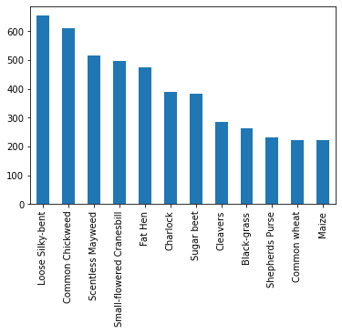

```python
# Plot of label types numbers
y.value_counts().plot(kind="bar")
```

```python
print(X.shape, y1.shape)
```

```
(4750, 100, 100, 1) (4750, 12)
```

#### Split train and test data

```python
# Splitting data into training, and test set
# Use stratify to maintain the proportionality of the data in test
X_train, X_test, y_train, y_test = train_test_split(
    X, y1, test_size=0.30, random_state=seed, stratify=y
)
```

```python
print(X_train.shape, X_test.shape)
print(X_test.shape, y_test.shape)
```

```
(3325, 100, 100, 1) (1425, 100, 100, 1)
(1425, 100, 100, 1) (1425, 12)
```

### **Model Building**

This analysis will use following Deep Neural Networks:

- **ANN** (Artificial Neural Network - fully connected)
- **CNN** (Convolutional Neural Network)

### Artificial Neural Network (ANN)

**Model 1:** Fully connected ANN.

#### Model Architectuure

- ANN has following characteristics.
  - Three fully connected dense layer with 512, 128 and 12 neurons each.
    - Hidden layer has ReLU activation function.
    - Output layer has softmax activation function for classification.
  - One dropout layer with probability of 0.5 is added between dense layer to **prevent overfitting**

```python
ann = Sequential()

ann.add(Flatten(input_shape=(scale, scale)))

# Adding a fully connected layer with 700 neurons
ann.add(Dense(units=512, activation="relu"))

# Adding dropout with probability 0.5
ann.add(Dropout(0.5))

# Adding a fully connected layer with 250 neurons
ann.add(Dense(units=128, activation="relu"))

# The final output layer with 12 neurons to predict the categorical classifcation
ann.add(Dense(units=12, activation="softmax"))

ann.compile(loss="categorical_crossentropy", optimizer="adam", metrics=["accuracy"])

ann.summary()
```

```
Model: "sequential"
_________________________________________________________________
Layer (type)                 Output Shape              Param #
=================================================================
flatten (Flatten)            (None, 10000)             0
_________________________________________________________________
dense (Dense)                (None, 512)               5120512
_________________________________________________________________
dropout (Dropout)            (None, 512)               0
_________________________________________________________________
dense_1 (Dense)              (None, 128)               65664
_________________________________________________________________
dense_2 (Dense)              (None, 12)                1548
=================================================================
Total params: 5,187,724
Trainable params: 5,187,724
Non-trainable params: 0
_________________________________________________________________
```

```
2021-10-13 14:30:00.069202: I tensorflow/core/platform/cpu_feature_guard.cc:142] This TensorFlow binary is optimized with oneAPI Deep Neural Network Library (oneDNN) to use the following CPU instructions in performance-critical operations:  SSE4.1 SSE4.2 AVX AVX2 FMA
To enable them in other operations, rebuild TensorFlow with the appropriate compiler flags.
```

#### Callbacks

Early stopping is used to stop training when a monitored metric has stopped improving.

Model check point is used to save a model when maximum accuuracy is reached

```python
es = EarlyStopping(monitor="val_loss", mode="min", verbose=1, patience=20)
mc = ModelCheckpoint(
    "best_model_ann.h5",
    monitor="val_accuracy",
    mode="max",
    verbose=1,
    save_best_only=True,
)
```

#### Model training

Train the model for a 30 epochs (iterations on a dataset) with the batch size of 64 and call backs.

```python
ann_history = ann.fit(
    X_train,
    y_train,
    epochs=EPOCHS,
    batch_size=BATCH_SIZE,
    validation_split=0.20,
    callbacks=[es, mc],
)
```

```
2021-10-13 14:30:00.396045: I tensorflow/compiler/mlir/mlir_graph_optimization_pass.cc:116] None of the MLIR optimization passes are enabled (registered 2)
```

```
Epoch 00001: val_accuracy improved from -inf to 0.10827, saving model to best_model_ann.h5

Epoch 00002: val_accuracy improved from 0.10827 to 0.13835, saving model to best_model_ann.h5

Epoch 00003: val_accuracy did not improve from 0.13835

Epoch 00004: val_accuracy did not improve from 0.13835

Epoch 00005: val_accuracy did not improve from 0.13835

Epoch 00006: val_accuracy did not improve from 0.13835

Epoch 00007: val_accuracy did not improve from 0.13835

Epoch 00008: val_accuracy did not improve from 0.13835

Epoch 00009: val_accuracy did not improve from 0.13835

Epoch 00010: val_accuracy did not improve from 0.13835

Epoch 00011: val_accuracy did not improve from 0.13835

Epoch 00012: val_accuracy did not improve from 0.13835

Epoch 00013: val_accuracy did not improve from 0.13835

Epoch 00014: val_accuracy did not improve from 0.13835

Epoch 00015: val_accuracy did not improve from 0.13835

Epoch 00016: val_accuracy did not improve from 0.13835

Epoch 00017: val_accuracy did not improve from 0.13835

Epoch 00018: val_accuracy did not improve from 0.13835

Epoch 00019: val_accuracy did not improve from 0.13835

Epoch 00020: val_accuracy did not improve from 0.13835

Epoch 00021: val_accuracy did not improve from 0.13835

Epoch 00022: val_accuracy did not improve from 0.13835

Epoch 00023: val_accuracy did not improve from 0.13835

Epoch 00024: val_accuracy did not improve from 0.13835

Epoch 00025: val_accuracy improved from 0.13835 to 0.16241, saving model to best_model_ann.h5

Epoch 00026: val_accuracy did not improve from 0.16241

Epoch 00027: val_accuracy improved from 0.16241 to 0.17293, saving model to best_model_ann.h5

Epoch 00028: val_accuracy did not improve from 0.17293

Epoch 00029: val_accuracy did not improve from 0.17293

Epoch 00030: val_accuracy did not improve from 0.17293
```

#### Model save

Save the CNN model and weights in H5 format.

```python
ann.save("./ann.h5")  # saveclassifier (model) and architecture to single file

ann.save_weights("./ann_weights.h5")  # weights are saved directly from the model.
```

#### Model evaluate

Evaluate the CNN model with test data to guage its performance.

```python
# Printing results
annresults = ann.evaluate(X_test, y_test, return_dict=True)
```

### **Convolutional Neural Network (CNN)**

**Model 2:** Relu CNN with three layers in convnet, three layers in dense and one dropout only in the dense network.

#### Model Architecture

Model architecture consists of CNN and ANN layers.

```python
# Initialising the CNN classifier
cnn = Sequential()

# Add a Convolution layer with 32 kernels of 3X3 shape with activation function ReLU
cnn.add(
    Conv2D(32, (3, 3), input_shape=(scale, scale, 1), activation="relu", padding="same")
)

# Add a Max Pooling layer of size 2X2
cnn.add(MaxPooling2D(pool_size=(2, 2)))

# Add another Convolution layer with 32 kernels of 3X3 shape with activation function ReLU
cnn.add(Conv2D(32, (3, 3), activation="relu", padding="same"))

# Adding another pooling layer
cnn.add(MaxPooling2D(pool_size=(2, 2)))

# Add another Convolution layer with 32 kernels of 3X3 shape with activation function ReLU
cnn.add(Conv2D(32, (3, 3), activation="relu", padding="valid"))

# Adding another pooling layer
cnn.add(MaxPooling2D(pool_size=(2, 2)))

# Flattening the layer before fully connected layers
cnn.add(Flatten())

# Adding a fully connected layer with 512 neurons#
cnn.add(Dense(units=512, activation="relu"))

# Adding dropout with probability 0.5
cnn.add(Dropout(0.5))

# Adding a fully connected layer with 128 neurons
cnn.add(Dense(units=128, activation="relu"))

# The final output layer with 10 neurons to predict the categorical classifcation
cnn.add(Dense(units=12, activation="softmax"))

cnn.summary()
```

```
Model: "sequential_1"
_________________________________________________________________
Layer (type)                 Output Shape              Param #
=================================================================
conv2d (Conv2D)              (None, 100, 100, 32)      320
_________________________________________________________________
max_pooling2d (MaxPooling2D) (None, 50, 50, 32)        0
_________________________________________________________________
conv2d_1 (Conv2D)            (None, 50, 50, 32)        9248
_________________________________________________________________
max_pooling2d_1 (MaxPooling2 (None, 25, 25, 32)        0
_________________________________________________________________
conv2d_2 (Conv2D)            (None, 23, 23, 32)        9248
_________________________________________________________________
max_pooling2d_2 (MaxPooling2 (None, 11, 11, 32)        0
_________________________________________________________________
flatten_1 (Flatten)          (None, 3872)              0
_________________________________________________________________
dense_3 (Dense)              (None, 512)               1982976
_________________________________________________________________
dropout_1 (Dropout)          (None, 512)               0
_________________________________________________________________
dense_4 (Dense)              (None, 128)               65664
_________________________________________________________________
dense_5 (Dense)              (None, 12)                1548
=================================================================
Total params: 2,069,004
Trainable params: 2,069,004
Non-trainable params: 0
_________________________________________________________________
```

#### Model clone

Clone this CNN model architecture for future use.

```python
cnn_1 = clone_model(cnn)
```

#### Model compile

Configure CNN model for training.

```python
""" Compile model (using the efficient Adam gradient descent optimization algorithm
    with a logarithmic loss function, which is called “categorical_crossentropy” in Keras.)"""
cnn.compile(optimizer="adam", loss="categorical_crossentropy", metrics=["accuracy"])
```

#### Callbacks

Early stopping is used to stop training when a monitored metric has stopped improving.

Model check point is used to save a model when maximum accuuracy is reached

```python
cnnes = EarlyStopping(monitor="val_loss", mode="min", verbose=1, patience=5)
cnnmc = ModelCheckpoint(
    "best_model_cnn.h5",
    monitor="val_accuracy",
    mode="max",
    verbose=1,
    save_best_only=True,
)
```

#### Data Augmentation

The purpose of data auugmentation is to reduce overfitting during learning process. ImageDataGenerator is used to generate batches of tensor image data with real-time data augmentation. Following data augumentation parameters are used.

- Images are randomly rotated 10 degrees.
- Images are randomly shifted 5% to the left or right(horizontal shifts).
- Images are randomly shifted 5% to the up or down (vertical shifts).
- Images are randomly zoom between 90% (zoom in) and 110% (zoom out).
- Images are not randomly flipped horizontally or vertically.
- 20% of images reserved for validation.

```python
cnndatagen = ImageDataGenerator(
    rotation_range=10.0,
    width_shift_range=0.05,
    height_shift_range=0.05,
    zoom_range=0.1,
    horizontal_flip=False,
    vertical_flip=False,
    validation_split=0.2,
)
```

#### Training data augumentation

ImageDataGenerator flow takes data & label arrays, generates batches of augmented **training data**.

```python
cnntraining_set = cnndatagen.flow(X_train, y_train, batch_size=32, subset="training")
```

#### Validation data augumentation

ImageDataGenerator flow takes data & label arrays, generates batches of augmented **validation data**.

```python
cnnvalidation_set = cnndatagen.flow(X_train, y_train, batch_size=8, subset="validation")
```

#### Model training

```python
cnnhistory = cnn.fit(
    cnntraining_set,
    validation_data=cnnvalidation_set,
    epochs=EPOCHS,
    batch_size=BATCH_SIZE,
    callbacks=[cnnes, cnnmc],
)
```

```
Epoch 00001: val_accuracy improved from -inf to 0.12932, saving model to best_model_cnn.h5

Epoch 00002: val_accuracy improved from 0.12932 to 0.13985, saving model to best_model_cnn.h5

Epoch 00003: val_accuracy improved from 0.13985 to 0.14737, saving model to best_model_cnn.h5

Epoch 00004: val_accuracy improved from 0.14737 to 0.15639, saving model to best_model_cnn.h5

Epoch 00005: val_accuracy improved from 0.15639 to 0.17444, saving model to best_model_cnn.h5

Epoch 00006: val_accuracy improved from 0.17444 to 0.19549, saving model to best_model_cnn.h5

Epoch 00007: val_accuracy did not improve from 0.19549

Epoch 00008: val_accuracy improved from 0.19549 to 0.22857, saving model to best_model_cnn.h5

Epoch 00009: val_accuracy did not improve from 0.22857

Epoch 00010: val_accuracy improved from 0.22857 to 0.27669, saving model to best_model_cnn.h5

Epoch 00011: val_accuracy improved from 0.27669 to 0.29624, saving model to best_model_cnn.h5

Epoch 00012: val_accuracy improved from 0.29624 to 0.31278, saving model to best_model_cnn.h5

Epoch 00013: val_accuracy improved from 0.31278 to 0.38797, saving model to best_model_cnn.h5

Epoch 00014: val_accuracy improved from 0.38797 to 0.42406, saving model to best_model_cnn.h5

Epoch 00015: val_accuracy improved from 0.42406 to 0.43158, saving model to best_model_cnn.h5

Epoch 00016: val_accuracy improved from 0.43158 to 0.48421, saving model to best_model_cnn.h5

Epoch 00017: val_accuracy did not improve from 0.48421

Epoch 00018: val_accuracy did not improve from 0.48421

Epoch 00019: val_accuracy improved from 0.48421 to 0.53534, saving model to best_model_cnn.h5

Epoch 00020: val_accuracy improved from 0.53534 to 0.54286, saving model to best_model_cnn.h5

Epoch 00021: val_accuracy improved from 0.54286 to 0.57143, saving model to best_model_cnn.h5

Epoch 00022: val_accuracy did not improve from 0.57143

Epoch 00023: val_accuracy did not improve from 0.57143

Epoch 00024: val_accuracy did not improve from 0.57143

Epoch 00025: val_accuracy did not improve from 0.57143

Epoch 00026: val_accuracy improved from 0.57143 to 0.59248, saving model to best_model_cnn.h5

Epoch 00027: val_accuracy did not improve from 0.59248

Epoch 00028: val_accuracy improved from 0.59248 to 0.62406, saving model to best_model_cnn.h5

Epoch 00029: val_accuracy did not improve from 0.62406

Epoch 00030: val_accuracy did not improve from 0.62406
```

#### Model save

Save the CNN model and weights in H5 format.

```python
cnn.save("./cnn.h5")  # saveclassifier (model) and architecture to single file

cnn.save_weights("./cnn_weights.h5")  # weights are saved directly from the model.
```

#### Model evaluate

Evaluate the CNN model with test data to guage its performance.

```python
# Printing results
cnnresults = cnn.evaluate(X_test, y_test, return_dict=True)
```

### **Convolutional Neural Network (CNN)**

**Model 2:** Relu CNN with one batch normalization in convnet and one dropout only in the dense network.

#### Model Architecture

Model architecture consists of CNN and ANN layers.

```python
# Initialising the CNN classifier
cnn1 = Sequential()

# Add a Convolution layer with 32 kernels of 3X3 shape with activation function ReLU
cnn1.add(
    Conv2D(32, (3, 3), input_shape=(scale, scale, 1), activation="relu", padding="same")
)

# Add a layer that normalizes its inputs
cnn1.add(BatchNormalization())

# Add a Max Pooling layer of size 2X2
cnn1.add(MaxPooling2D(pool_size=(2, 2)))

# Add another Convolution layer with 32 kernels of 3X3 shape with activation function ReLU
cnn1.add(Conv2D(32, (3, 3), activation="relu", padding="same"))

# Adding another pooling layer
cnn1.add(MaxPooling2D(pool_size=(2, 2)))

# Add another Convolution layer with 32 kernels of 3X3 shape with activation function ReLU
cnn1.add(Conv2D(32, (3, 3), activation="relu", padding="valid"))

# Adding another pooling layer
cnn1.add(MaxPooling2D(pool_size=(2, 2)))

# Flattening the layer before fully connected layers
cnn1.add(Flatten())

# Adding a fully connected layer with 512 neurons#
cnn1.add(Dense(units=512, activation="relu"))

# Adding dropout with probability 0.5
cnn1.add(Dropout(0.5))

# Adding a fully connected layer with 128 neurons
cnn1.add(Dense(units=128, activation="relu"))

# The final output layer with 10 neurons to predict the categorical classifcation
cnn1.add(Dense(units=12, activation="softmax"))

cnn1.summary()
```

```
Model: "sequential_2"
_________________________________________________________________
Layer (type)                 Output Shape              Param #
=================================================================
conv2d_3 (Conv2D)            (None, 100, 100, 32)      320
_________________________________________________________________
batch_normalization (BatchNo (None, 100, 100, 32)      128
_________________________________________________________________
max_pooling2d_3 (MaxPooling2 (None, 50, 50, 32)        0
_________________________________________________________________
conv2d_4 (Conv2D)            (None, 50, 50, 32)        9248
_________________________________________________________________
max_pooling2d_4 (MaxPooling2 (None, 25, 25, 32)        0
_________________________________________________________________
conv2d_5 (Conv2D)            (None, 23, 23, 32)        9248
_________________________________________________________________
max_pooling2d_5 (MaxPooling2 (None, 11, 11, 32)        0
_________________________________________________________________
flatten_2 (Flatten)          (None, 3872)              0
_________________________________________________________________
dense_6 (Dense)              (None, 512)               1982976
_________________________________________________________________
dropout_2 (Dropout)          (None, 512)               0
_________________________________________________________________
dense_7 (Dense)              (None, 128)               65664
_________________________________________________________________
dense_8 (Dense)              (None, 12)                1548
=================================================================
Total params: 2,069,132
Trainable params: 2,069,068
Non-trainable params: 64
_________________________________________________________________
```

#### Model clone

Clone this CNN model architecture for future use.

```python
cnn1_1 = clone_model(cnn1)
```

#### Model compile

Configure CNN model for training.

```python
""" Compile model (using the efficient Adam gradient descent optimization algorithm
    with a logarithmic loss function, which is called “categorical_crossentropy” in Keras.)"""
cnn1.compile(optimizer="adam", loss="categorical_crossentropy", metrics=["accuracy"])
```

#### Callbacks

Early stopping is used to stop training when a monitored metric has stopped improving.

Model check point is used to save a model when maximum accuuracy is reached

```python
cnn1es = EarlyStopping(monitor="val_loss", mode="min", verbose=1, patience=5)
cnn1mc = ModelCheckpoint(
    "best_model_cnn1.h5",
    monitor="val_accuracy",
    mode="max",
    verbose=1,
    save_best_only=True,
)
```

#### Data Augmentation

The purpose of data auugmentation is to reduce overfitting during learning process. ImageDataGenerator is used to generate batches of tensor image data with real-time data augmentation. Following data augumentation parameters are used.

- Images are randomly rotated 10 degrees.
- Images are randomly shifted 5% to the left or right(horizontal shifts).
- Images are randomly shifted 5% to the up or down (vertical shifts).
- Images are randomly zoom between 90% (zoom in) and 110% (zoom out).
- Images are not randomly flipped horizontally or vertically.
- 20% of images reserved for validation.

```python
cnn1datagen = ImageDataGenerator(
    rotation_range=10.0,
    width_shift_range=0.05,
    height_shift_range=0.05,
    zoom_range=0.1,
    horizontal_flip=False,
    vertical_flip=False,
    validation_split=0.2,
)
```

#### Training data augumentation

ImageDataGenerator flow takes data & label arrays, generates batches of augmented **training data**.

```python
cnn1training_set = cnn1datagen.flow(X_train, y_train, batch_size=32, subset="training")
```

#### Validation data augumentation

ImageDataGenerator flow takes data & label arrays, generates batches of augmented **validation data**.

```python
cnn1validation_set = cnn1datagen.flow(
    X_train, y_train, batch_size=8, subset="validation"
)
```

#### Model training

```python
cnn1history = cnn1.fit(
    cnn1training_set,
    validation_data=cnn1validation_set,
    epochs=EPOCHS,
    batch_size=BATCH_SIZE,
    callbacks=[cnn1es, cnn1mc],
)
```

```
Epoch 00001: val_accuracy improved from -inf to 0.11128, saving model to best_model_cnn1.h5

Epoch 00002: val_accuracy did not improve from 0.11128

Epoch 00003: val_accuracy improved from 0.11128 to 0.15789, saving model to best_model_cnn1.h5

Epoch 00004: val_accuracy did not improve from 0.15789

Epoch 00005: val_accuracy improved from 0.15789 to 0.36541, saving model to best_model_cnn1.h5

Epoch 00006: val_accuracy did not improve from 0.36541

Epoch 00007: val_accuracy did not improve from 0.36541

Epoch 00008: val_accuracy improved from 0.36541 to 0.47218, saving model to best_model_cnn1.h5

Epoch 00009: val_accuracy improved from 0.47218 to 0.50827, saving model to best_model_cnn1.h5

Epoch 00010: val_accuracy did not improve from 0.50827

Epoch 00011: val_accuracy did not improve from 0.50827

Epoch 00012: val_accuracy improved from 0.50827 to 0.57293, saving model to best_model_cnn1.h5

Epoch 00013: val_accuracy did not improve from 0.57293

Epoch 00014: val_accuracy did not improve from 0.57293

Epoch 00015: val_accuracy did not improve from 0.57293

Epoch 00016: val_accuracy improved from 0.57293 to 0.57594, saving model to best_model_cnn1.h5

Epoch 00017: val_accuracy did not improve from 0.57594

Epoch 00018: val_accuracy improved from 0.57594 to 0.58195, saving model to best_model_cnn1.h5

Epoch 00019: val_accuracy improved from 0.58195 to 0.61504, saving model to best_model_cnn1.h5
Epoch 00019: early stopping
```

#### Model save

Save the CNN model and weights in H5 format.

```python
cnn1.save("./cnn1.h5")  # saveclassifier (model) and architecture to single file

cnn1.save_weights("./cnn1_weights.h5")  # weights are saved directly from the model.
```

#### Model evaluate

Evaluate the CNN model with test data to guage its performance.

```python
# Printing results
cnn1results = cnn1.evaluate(X_test, y_test, return_dict=True)
```

### Convolutional Neural Network (CNN)

**Model 2.1:** Evaluating cloned ReLu CNN model (Model 2) with an modified ImageDataGenerator (Additional configuration)

#### Model compile and callbacks

```python
cnn1_1.compile(optimizer="adam", loss="categorical_crossentropy", metrics=["accuracy"])

cnn1_1es = EarlyStopping(monitor="val_loss", mode="min", verbose=1, patience=5)

cnn1_1mc = ModelCheckpoint(
    "best_model_cnn1_1.h5",
    monitor="val_accuracy",
    mode="max",
    verbose=1,
    save_best_only=True,
)
```

#### Data Augumentation

- Images are randomly rotated 10 degrees.
- Images are randomly shifted 10% to the left or right(horizontal shifts).
- Images are randomly shifted 10% to the up or down (vertical shifts).
- Images are randomly zoom between 90% (zoom in) and 110% (zoom out).
- Images are not randomly flipped horizontally or vertically.
- Images mean set to 0
- 20% of images reserved for validation.

```python
# Another popular pixel scaling method is to calculate the mean pixel value across the entire training dataset, then subtract it from each image

cnn1_1datagen = ImageDataGenerator(
    rotation_range=10.0,
    samplewise_center=True,
    width_shift_range=0.1,
    height_shift_range=0.1,
    zoom_range=0.1,
    horizontal_flip=False,
    vertical_flip=False,
    validation_split=0.2,
)

cnn1_1training_set = cnn1_1datagen.flow(
    X_train, y_train, batch_size=32, subset="training"
)

cnn1_1validation_set = cnn1_1datagen.flow(
    X_train, y_train, batch_size=8, subset="validation"
)
```

#### Train and save the model

```python
cnn1_1history = cnn1_1.fit(
    cnn1_1training_set,
    validation_data=cnn1_1validation_set,
    epochs=EPOCHS,
    batch_size=BATCH_SIZE,
    callbacks=[cnn1_1es, cnn1_1mc],
)

cnn1_1.save("./cnn1_1.h5")  # saveclassifier (model) and architecture to single file

cnn1_1.save_weights("./cnn1_1_weights.h5")  # weights are saved directly from the model.
```

```
Epoch 00001: val_accuracy improved from -inf to 0.15338, saving model to best_model_cnn1_1.h5

Epoch 00002: val_accuracy did not improve from 0.15338

Epoch 00003: val_accuracy did not improve from 0.15338

Epoch 00004: val_accuracy improved from 0.15338 to 0.25263, saving model to best_model_cnn1_1.h5

Epoch 00005: val_accuracy improved from 0.25263 to 0.30526, saving model to best_model_cnn1_1.h5

Epoch 00006: val_accuracy improved from 0.30526 to 0.42556, saving model to best_model_cnn1_1.h5

Epoch 00007: val_accuracy did not improve from 0.42556

Epoch 00008: val_accuracy improved from 0.42556 to 0.48722, saving model to best_model_cnn1_1.h5

Epoch 00009: val_accuracy did not improve from 0.48722

Epoch 00010: val_accuracy did not improve from 0.48722

Epoch 00011: val_accuracy improved from 0.48722 to 0.50677, saving model to best_model_cnn1_1.h5

Epoch 00012: val_accuracy improved from 0.50677 to 0.54135, saving model to best_model_cnn1_1.h5

Epoch 00013: val_accuracy improved from 0.54135 to 0.54586, saving model to best_model_cnn1_1.h5

Epoch 00014: val_accuracy did not improve from 0.54586

Epoch 00015: val_accuracy improved from 0.54586 to 0.57143, saving model to best_model_cnn1_1.h5

Epoch 00016: val_accuracy improved from 0.57143 to 0.60150, saving model to best_model_cnn1_1.h5

Epoch 00017: val_accuracy did not improve from 0.60150

Epoch 00018: val_accuracy did not improve from 0.60150

Epoch 00019: val_accuracy did not improve from 0.60150

Epoch 00020: val_accuracy did not improve from 0.60150

Epoch 00021: val_accuracy did not improve from 0.60150
Epoch 00021: early stopping
```

#### Evaluate the model

```python
# Printing results
cnn1_1results = cnn1_1.evaluate(X_test, y_test, return_dict=True)
```

### **Convolutional Neural Network (CNN)**

**Model 2:** LeakyReLU CNN with no batch normalization and dropout in both Convolution and Dense network

#### Model Architecture

CNN has following characteristics.

Data from the CNN is flattened before passing it to ANN.

- Flattening is converting the data into a 1-dimensional array for inputting it to the next layer

ANN has following characteristics.

- Three fully connected dense layer with 512, 256 and 12 neurons each.
  - Hidden layer has LeakyReLU activation function.
  - Output layer has softmax activation function for classification.

```python
# Initialising the CNN classifier
cnn2 = Sequential()

# Add a Convolution layer with 32 kernels of 3X3 shape with activation function ReLU
cnn2.add(
    Conv2D(
        16,
        (5, 5),
        input_shape=(scale, scale, 1),
        activation=LeakyReLU(alpha=0.1),
        padding="same",
    )
)

# Adding dropout with probability 0.25
cnn2.add(Dropout(0.25))

# Add a Max Pooling layer of size 2X2
cnn2.add(MaxPooling2D(pool_size=(2, 2)))

# Add another Convolution layer with 16 kernels of 5X5 shape with activation function ReLU
cnn2.add(Conv2D(16, (5, 5), activation=LeakyReLU(alpha=0.1), padding="same"))

# Adding dropout with probability 0.25
cnn2.add(Dropout(0.25))

# Adding another pooling layer
cnn2.add(MaxPooling2D(pool_size=(2, 2)))

# Add another Convolution layer with 16 kernels of 5X5 shape with activation function ReLU
cnn2.add(Conv2D(16, (5, 5), activation=LeakyReLU(alpha=0.1), padding="valid"))

# Adding dropout with probability 0.25
cnn2.add(Dropout(0.25))

# Adding another pooling layer
cnn2.add(MaxPooling2D(pool_size=(2, 2)))

# Flattening the layer before fully connected layers
cnn2.add(Flatten())

# Adding a fully connected layer with 512 neurons
cnn2.add(Dense(units=512, activation=LeakyReLU(alpha=0.1)))

# Adding dropout with probability 0.5
cnn2.add(Dropout(0.5))


# Adding a fully connected layer with 125628 neurons
cnn2.add(Dense(units=256, activation=LeakyReLU(alpha=0.1)))


# The final output layer with 10 neurons to predict the categorical classifcation
cnn2.add(Dense(units=12, activation="softmax"))

cnn2.summary()
```

```
Model: "sequential_3"
_________________________________________________________________
Layer (type)                 Output Shape              Param #
=================================================================
conv2d_6 (Conv2D)            (None, 100, 100, 16)      416
_________________________________________________________________
dropout_3 (Dropout)          (None, 100, 100, 16)      0
_________________________________________________________________
max_pooling2d_6 (MaxPooling2 (None, 50, 50, 16)        0
_________________________________________________________________
conv2d_7 (Conv2D)            (None, 50, 50, 16)        6416
_________________________________________________________________
dropout_4 (Dropout)          (None, 50, 50, 16)        0
_________________________________________________________________
max_pooling2d_7 (MaxPooling2 (None, 25, 25, 16)        0
_________________________________________________________________
conv2d_8 (Conv2D)            (None, 21, 21, 16)        6416
_________________________________________________________________
dropout_5 (Dropout)          (None, 21, 21, 16)        0
_________________________________________________________________
max_pooling2d_8 (MaxPooling2 (None, 10, 10, 16)        0
_________________________________________________________________
flatten_3 (Flatten)          (None, 1600)              0
_________________________________________________________________
dense_9 (Dense)              (None, 512)               819712
_________________________________________________________________
dropout_6 (Dropout)          (None, 512)               0
_________________________________________________________________
dense_10 (Dense)             (None, 256)               131328
_________________________________________________________________
dense_11 (Dense)             (None, 12)                3084
=================================================================
Total params: 967,372
Trainable params: 967,372
Non-trainable params: 0
_________________________________________________________________
```

```python
""" Compile model (using the efficient Adam gradient descent optimization algorithm
    with a logarithmic loss function, which is called “categorical_crossentropy” in Keras.)"""
cnn2.compile(optimizer="adam", loss="categorical_crossentropy", metrics=["accuracy"])
```

```python
cnn2es = EarlyStopping(monitor="val_loss", mode="min", verbose=1, patience=5)
cnn2mc = ModelCheckpoint(
    "best_model_cnn2.h5",
    monitor="val_accuracy",
    mode="max",
    verbose=1,
    save_best_only=True,
)
```

```python
## data augmentation

# Generate new images via rotations, translations, flippings

cnn2datagen = ImageDataGenerator(
    rotation_range=10.0,
    width_shift_range=0.05,
    height_shift_range=0.05,
    zoom_range=0.1,
    horizontal_flip=False,
    vertical_flip=False,
    validation_split=0.2,
)
```

```python
cnn2training_set = cnn2datagen.flow(X_train, y_train, batch_size=32, subset="training")
```

```python
cnn2validation_set = cnn2datagen.flow(
    X_train, y_train, batch_size=8, subset="validation"
)
```

```python
cnn2history = cnn2.fit(
    cnn2training_set,
    validation_data=cnn2validation_set,
    epochs=EPOCHS,
    batch_size=BATCH_SIZE,
    callbacks=[cnn2es, cnn2mc],
)
```

```
Epoch 00001: val_accuracy improved from -inf to 0.12632, saving model to best_model_cnn2.h5

Epoch 00002: val_accuracy improved from 0.12632 to 0.15639, saving model to best_model_cnn2.h5

Epoch 00003: val_accuracy did not improve from 0.15639

Epoch 00004: val_accuracy did not improve from 0.15639

Epoch 00005: val_accuracy did not improve from 0.15639

Epoch 00006: val_accuracy improved from 0.15639 to 0.15789, saving model to best_model_cnn2.h5

Epoch 00007: val_accuracy improved from 0.15789 to 0.16692, saving model to best_model_cnn2.h5

Epoch 00008: val_accuracy improved from 0.16692 to 0.17293, saving model to best_model_cnn2.h5

Epoch 00009: val_accuracy did not improve from 0.17293

Epoch 00010: val_accuracy did not improve from 0.17293

Epoch 00011: val_accuracy did not improve from 0.17293

Epoch 00012: val_accuracy improved from 0.17293 to 0.20752, saving model to best_model_cnn2.h5

Epoch 00013: val_accuracy did not improve from 0.20752
Epoch 00013: early stopping
```

```python
cnn2.save("./cnn2.h5")  # saveclassifier (model) and architecture to single file

cnn2.save_weights("./cnn2_weights.h5")  # weights are saved directly from the model.
```

```python
# Printing results
cnn2results = cnn2.evaluate(X_test, y_test, return_dict=True)
```

### Model Evaluation

#### ANN Model

```python
annhist = pd.DataFrame(ann_history.history)
annhist.head()
```

|  | loss | accuracy | val_loss | val_accuracy |
| --- | --- | --- | --- | --- |
| 0 | 3.002162 | 0.111654 | 2.450447 | 0.108271 |
| 1 | 2.466921 | 0.124436 | 2.463435 | 0.138346 |
| 2 | 2.449149 | 0.135338 | 2.417415 | 0.138346 |
| 3 | 2.438669 | 0.137594 | 2.415565 | 0.138346 |
| 4 | 2.441005 | 0.137594 | 2.428100 | 0.138346 |

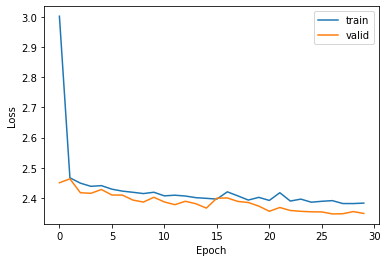

```python
# Capturing learning history per epoch

annhist["epoch"] = ann_history.epoch

# Plotting accuracy at different epochs
plt.plot(annhist["loss"])
plt.plot(annhist["val_loss"])
plt.xlabel("Epoch")
plt.ylabel("Loss")
plt.legend(("train", "valid"), loc=0)
```

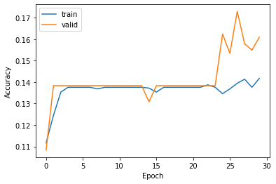

```python
# Plotting accuracy at different epochs
plt.plot(annhist["accuracy"])
plt.plot(annhist["val_accuracy"])
plt.xlabel("Epoch")
plt.ylabel("Accuracy")
plt.legend(("train", "valid"), loc=0)
plt.show()
```

```python
annprediction = np.round(ann.predict(X_test, 0))
```

```python
annclassification_metrics = metrics.classification_report(
    y_test, annprediction, target_names=classes
)
```

```python
print(annclassification_metrics)
```

```
                           precision    recall  f1-score   support

              Black-grass       0.00      0.00      0.00        79
                 Charlock       0.00      0.00      0.00       117
                 Cleavers       0.00      0.00      0.00        86
         Common Chickweed       0.00      0.00      0.00       183
             Common wheat       0.00      0.00      0.00        66
                  Fat Hen       0.00      0.00      0.00       143
         Loose Silky-bent       0.00      0.00      0.00       196
                    Maize       0.00      0.00      0.00        66
        Scentless Mayweed       0.00      0.00      0.00       155
          Shepherds Purse       0.00      0.00      0.00        69
Small-flowered Cranesbill       0.00      0.00      0.00       149
               Sugar beet       0.00      0.00      0.00       116

                micro avg       0.00      0.00      0.00      1425
                macro avg       0.00      0.00      0.00      1425
             weighted avg       0.00      0.00      0.00      1425
              samples avg       0.00      0.00      0.00      1425
```

#### Relu CNN Model

```python
cnnhist = pd.DataFrame(cnnhistory.history)
cnnhist.head()
```

|  | loss | accuracy | val_loss | val_accuracy |
| --- | --- | --- | --- | --- |
| 0 | 2.431067 | 0.128571 | 2.444415 | 0.129323 |
| 1 | 2.420477 | 0.139474 | 2.440222 | 0.139850 |
| 2 | 2.402543 | 0.151504 | 2.379839 | 0.147368 |
| 3 | 2.365324 | 0.159398 | 2.355530 | 0.156391 |
| 4 | 2.338323 | 0.165414 | 2.327063 | 0.174436 |

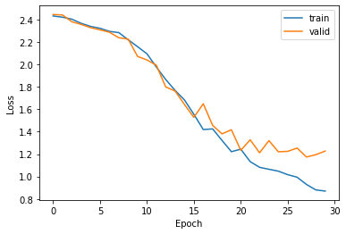

```python
# Capturing learning history per epoch

cnnhist["epoch"] = cnnhistory.epoch

# Plotting accuracy at different epochs
plt.plot(cnnhist["loss"])
plt.plot(cnnhist["val_loss"])
plt.xlabel("Epoch")
plt.ylabel("Loss")
plt.legend(("train", "valid"), loc=0)
```

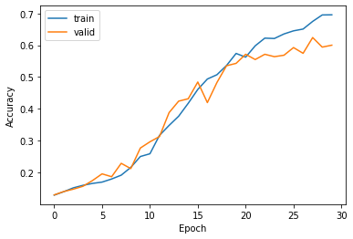

```python
# Plotting accuracy at different epochs
plt.plot(cnnhist["accuracy"])
plt.plot(cnnhist["val_accuracy"])
plt.xlabel("Epoch")
plt.ylabel("Accuracy")
plt.legend(("train", "valid"), loc=0)
plt.show()
```

```python
cnnprediction = np.round(cnn.predict(X_test, 0))
```

```python
cnnclassification_metrics = metrics.classification_report(
    y_test, cnnprediction, target_names=classes
)
```

```python
print(cnnclassification_metrics)
```

```
                           precision    recall  f1-score   support

              Black-grass       0.55      0.20      0.30        79
                 Charlock       0.75      0.59      0.66       117
                 Cleavers       0.83      0.47      0.60        86
         Common Chickweed       0.65      0.61      0.63       183
             Common wheat       0.59      0.33      0.43        66
                  Fat Hen       0.79      0.48      0.60       143
         Loose Silky-bent       0.59      0.58      0.58       196
                    Maize       0.91      0.48      0.63        66
        Scentless Mayweed       0.67      0.50      0.58       155
          Shepherds Purse       0.78      0.20      0.32        69
Small-flowered Cranesbill       0.75      0.81      0.78       149
               Sugar beet       0.70      0.59      0.64       116

                micro avg       0.70      0.53      0.60      1425
                macro avg       0.72      0.49      0.56      1425
             weighted avg       0.70      0.53      0.59      1425
              samples avg       0.53      0.53      0.53      1425
```

#### Relu CNN Model with batch normalization

```python
cnn1hist = pd.DataFrame(cnn1history.history)
cnn1hist.head()
```

|  | loss | accuracy | val_loss | val_accuracy |
| --- | --- | --- | --- | --- |
| 0 | 2.424268 | 0.136466 | 2.466383 | 0.111278 |
| 1 | 2.280839 | 0.196617 | 2.471062 | 0.111278 |
| 2 | 2.124709 | 0.251880 | 2.373150 | 0.157895 |
| 3 | 1.969857 | 0.322180 | 2.516662 | 0.114286 |
| 4 | 1.733304 | 0.407895 | 2.001875 | 0.365414 |

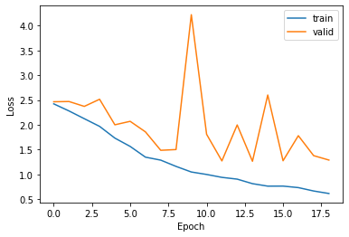

```python
# Capturing learning history per epoch

cnn1hist["epoch"] = cnn1history.epoch

# Plotting accuracy at different epochs
plt.plot(cnn1hist["loss"])
plt.plot(cnn1hist["val_loss"])
plt.xlabel("Epoch")
plt.ylabel("Loss")
plt.legend(("train", "valid"), loc=0)
```

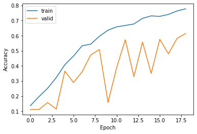

```python
# Plotting accuracy at different epochs
plt.plot(cnn1hist["accuracy"])
plt.plot(cnn1hist["val_accuracy"])
plt.xlabel("Epoch")
plt.ylabel("Accuracy")
plt.legend(("train", "valid"), loc=0)
plt.show()
```

```python
cnn1prediction = np.round(cnn1.predict(X_test, 0))
```

```python
cnn1classification_metrics = metrics.classification_report(
    y_test, cnn1prediction, target_names=classes
)
```

```python
print(cnn1classification_metrics)
```

```
                           precision    recall  f1-score   support

              Black-grass       0.45      0.25      0.33        79
                 Charlock       0.60      0.70      0.65       117
                 Cleavers       0.95      0.41      0.57        86
         Common Chickweed       0.66      0.60      0.63       183
             Common wheat       0.39      0.17      0.23        66
                  Fat Hen       0.80      0.58      0.67       143
         Loose Silky-bent       0.63      0.36      0.46       196
                    Maize       0.69      0.67      0.68        66
        Scentless Mayweed       0.68      0.46      0.55       155
          Shepherds Purse       0.59      0.25      0.35        69
Small-flowered Cranesbill       0.83      0.79      0.81       149
               Sugar beet       0.49      0.81      0.61       116

                micro avg       0.65      0.53      0.58      1425
                macro avg       0.65      0.50      0.54      1425
             weighted avg       0.66      0.53      0.57      1425
              samples avg       0.53      0.53      0.53      1425
```

#### LeakyRelu CNN Model

```python
cnn2hist = pd.DataFrame(cnn2history.history)
cnn2hist.head()
```

|  | loss | accuracy | val_loss | val_accuracy |
| --- | --- | --- | --- | --- |
| 0 | 2.436836 | 0.126316 | 2.441239 | 0.126316 |
| 1 | 2.414213 | 0.143609 | 2.431975 | 0.156391 |
| 2 | 2.402443 | 0.151504 | 2.453934 | 0.117293 |
| 3 | 2.388734 | 0.152632 | 2.476490 | 0.118797 |
| 4 | 2.356809 | 0.163910 | 2.474823 | 0.138346 |

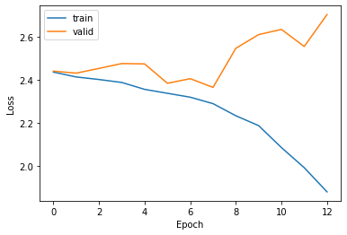

```python
# Capturing learning history per epoch

cnn2hist["epoch"] = cnn2history.epoch

# Plotting accuracy at different epochs
plt.plot(cnn2hist["loss"])
plt.plot(cnn2hist["val_loss"])
plt.xlabel("Epoch")
plt.ylabel("Loss")
plt.legend(("train", "valid"), loc=0)
```

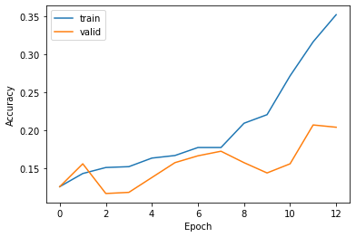

```python
# Plotting accuracy at different epochs
plt.plot(cnn2hist["accuracy"])
plt.plot(cnn2hist["val_accuracy"])
plt.xlabel("Epoch")
plt.ylabel("Accuracy")
plt.legend(("train", "valid"), loc=0)
plt.show()
```

```python
cnn2prediction = np.round(cnn2.predict(X_test, 0))
```

```python
cnn2classification_metrics = metrics.classification_report(
    y_test, cnn2prediction, target_names=classes
)
```

```python
print(cnn2classification_metrics)
```

```
                           precision    recall  f1-score   support

              Black-grass       0.33      0.03      0.05        79
                 Charlock       0.30      0.05      0.09       117
                 Cleavers       0.50      0.01      0.02        86
         Common Chickweed       0.14      0.01      0.01       183
             Common wheat       0.00      0.00      0.00        66
                  Fat Hen       1.00      0.01      0.01       143
         Loose Silky-bent       0.67      0.03      0.06       196
                    Maize       0.43      0.20      0.27        66
        Scentless Mayweed       0.22      0.55      0.31       155
          Shepherds Purse       0.00      0.00      0.00        69
Small-flowered Cranesbill       0.43      0.04      0.07       149
               Sugar beet       0.75      0.03      0.05       116

                micro avg       0.26      0.09      0.13      1425
                macro avg       0.40      0.08      0.08      1425
             weighted avg       0.43      0.09      0.08      1425
              samples avg       0.09      0.09      0.09      1425
```

### **Model Comparison**

```python
comparison1 = pd.DataFrame(
    data=annresults,
    index=[0],
)
comparison2 = pd.DataFrame(
    data=cnnresults,
    index=[0],
)
comparison3 = pd.DataFrame(
    data=cnn1results,
    index=[0],
)

comparison3_1 = pd.DataFrame(
    data=cnn1_1results,
    index=[0],
)
comparison4 = pd.DataFrame(
    data=cnn2results,
    index=[0],
)
```

```python
models_comp_df = pd.concat(
    [
        comparison1.T,
        comparison2.T,
        comparison3.T,
        comparison3_1.T,
        comparison4.T,
    ],
    axis=1,
)
```

```python
models_comp_df.columns = [
    "ANN",
    "ReLu CNN",
    "ReLu CNN with Batch Normalization",
    "Relu CNN with Batch Normalization and strict agumentation",
    "Leaky ReLu CNN with drop outs",
]
```

```python
models_comp_df.T.sort_values(by=["accuracy"], ascending=False)
```

|  | loss | accuracy |
| --- | --- | --- |
| ReLu CNN | 1.238555 | 0.604912 |
| ReLu CNN with Batch Normalization | 1.507574 | 0.583158 |
| Leaky ReLu CNN with drop outs | 2.644679 | 0.194386 |
| ANN | 2.377297 | 0.148772 |
| Relu CNN with Batch Normalization and strict agumentation | 6.055437 | 0.051228 |

### Confusion matrix for the best model (ReLu CNN)

Compute the confusion matrix for the best model to understand the distribution of True Positives, False Positives, False Negatives and True Negatives.

```python
# Test Prediction
y_test_pred_cnn = cnn.predict(X_test)
y_test_pred_classes_cnn = np.argmax(y_test_pred_cnn, axis=1)
y_test_pred_prob_cnn = np.max(y_test_pred_cnn, axis=1)
y_test_cnn = np.argmax(y_test, axis=1)
```

```python
print(y_test_pred_classes_cnn)
print(y_test_pred_prob_cnn)
print(y_test_cnn)
```

```
[11  6 11 ...  6  8  5]
[0.9741856  0.80407876 0.5368974  ... 0.67452943 0.7593137  0.41250607]
[11  0 11 ...  6  8  6]
```

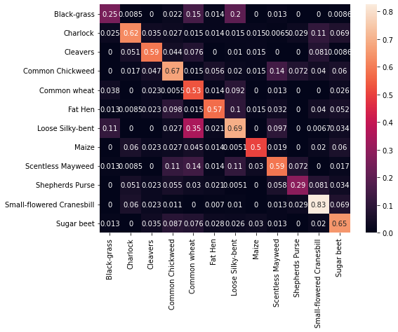

```python
cf_matrix = confusion_matrix(np.array(y_test_cnn), y_test_pred_classes_cnn)

# Confusion matrix normalized per category true value
cf_matrix_n1 = cf_matrix / np.sum(cf_matrix, axis=1)
plt.figure(figsize=(8, 6))
sns.heatmap(cf_matrix_n1, xticklabels=classes, yticklabels=classes, annot=True)
```

#### Observation:

- Model can predict the following seedlings.
  - sugar beet,
  - Small-flowered Cranesbill,
  - Loose Silky-bent, and
  - Common Chick wood.
- Model poorly predicts following seedlings.
  - common wheat,
  - Black grass, and
  - Shepherds Purse.
- Common wheat and Blackgrass are confused with Loose Silky-bent seedlings.

### Classification Report for the best model (ReLu CNN)

Compute F1 score (mean of precision and recall) and calculate classification performance.

```python
print(cnnclassification_metrics)
```

```
                           precision    recall  f1-score   support

              Black-grass       0.55      0.20      0.30        79
                 Charlock       0.75      0.59      0.66       117
                 Cleavers       0.83      0.47      0.60        86
         Common Chickweed       0.65      0.61      0.63       183
             Common wheat       0.59      0.33      0.43        66
                  Fat Hen       0.79      0.48      0.60       143
         Loose Silky-bent       0.59      0.58      0.58       196
                    Maize       0.91      0.48      0.63        66
        Scentless Mayweed       0.67      0.50      0.58       155
          Shepherds Purse       0.78      0.20      0.32        69
Small-flowered Cranesbill       0.75      0.81      0.78       149
               Sugar beet       0.70      0.59      0.64       116

                micro avg       0.70      0.53      0.60      1425
                macro avg       0.72      0.49      0.56      1425
             weighted avg       0.70      0.53      0.59      1425
              samples avg       0.53      0.53      0.53      1425
```

#### Observation:

As observed in confusion matrix following seedlings has poor score.

- common wheat,
- Black grass, and
- Shepherds Purse.

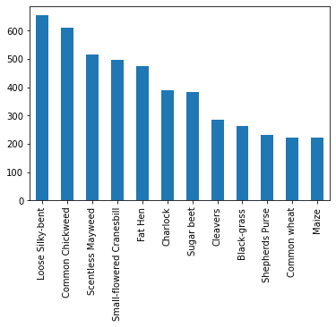

```python
# Plot of label types numbers
y.value_counts().plot(kind="bar")
```

### Scope of Improvement

- There is significant scope for improvement in the test accuracy and F1 score of the CNN model chosen here.
- Different architectures with tuned layers can obtain better accuracy.
- More analysis is needed to tune the Image data augmentation parameter.
- More research and analysis is needed on imbalanced data set to improve the accuracy of undersampled data. **(class_weight)**

### Conclusion and key takeaways

# Appendix - Additional analysis

## Build and evaluate selectd model with class weights.

```python
y_integers = np.argmax(y_train, axis=1)
uy = np.unique(y_integers)
class_weights = class_weight.compute_class_weight("balanced", classes=uy, y=y_integers)
d_class_weights = dict(enumerate(class_weights))
```

```python
cnn_1.compile(optimizer="adam", loss="categorical_crossentropy", metrics=["accuracy"])
```

```python
cnn_1history = cnn_1.fit(
    cnntraining_set,
    validation_data=cnnvalidation_set,
    epochs=EPOCHS,
    batch_size=BATCH_SIZE,
    class_weight = d_class_weights
    callbacks=[cnnes, cnnmc],
)

cnn_1.save("./cnn_1.h5")  # saveclassifier (model) and architecture to single file

cnn_1.save_weights("./cnn_1_weights.h5")  # weights are saved directly from the model.

# Printing results
cnn_1results = cnn_1.evaluate(X_test, y_test, return_dict=True)
```

[output not shown]

```python
cnn_1prediction = np.round(cnn_1.predict(X_test, 0))
```

```python
cnn_1classification_metrics = metrics.classification_report(
    y_test, cnn_1prediction, target_names=classes
)
```

```python
print(cnn_1classification_metrics)
```

```
                           precision    recall  f1-score   support

              Black-grass       0.46      0.16      0.24        79
                 Charlock       0.65      0.62      0.63       117
                 Cleavers       0.76      0.37      0.50        86
         Common Chickweed       0.70      0.53      0.60       183
             Common wheat       0.62      0.15      0.24        66
                  Fat Hen       0.67      0.51      0.58       143
         Loose Silky-bent       0.63      0.50      0.56       196
                    Maize       0.92      0.50      0.65        66
        Scentless Mayweed       0.69      0.48      0.56       155
          Shepherds Purse       0.65      0.16      0.26        69
Small-flowered Cranesbill       0.85      0.51      0.64       149
               Sugar beet       0.50      0.59      0.55       116

                micro avg       0.67      0.46      0.55      1425
                macro avg       0.68      0.42      0.50      1425
             weighted avg       0.68      0.46      0.53      1425
              samples avg       0.46      0.46      0.46      1425
```